# Analiza medijske pokrivenosti političke polarizacije u Hrvatskoj

Semantička analiza, konstrukcija indeksa i vremenske dinamike

Author

GIMES Research

Published

2. siječnja 2026.

# 1 Uvod

U ovom izvještaju se predstavlja sveobuhvatna analiza medijske pokrivenosti političke polarizacije u Hrvatskoj. Analizom se obuhvaća praćenje društvenih podjela, stranačkih sukoba, govora mržnje, povijesnih trauma i spornih društvenih pitanja temeljem članaka iz hrvatskih online medija.

## 1.1 Motivacija i kontekst

Politička polarizacija predstavlja rastući fenomen u suvremenim demokracijama, uključujući Hrvatsku. Ovim izvještajem se nastoji odgovoriti na ključna pitanja:

1. Kako se medijsko izvještavanje o polarizacijskim temama razvijalo kroz vrijeme?
2. Koje su kategorije polarizacije najzastupljenije u hrvatskim medijima?
3. Postoje li sezonski obrasci u intenzitetu polarizacijskog diskursa?
4. Kako se različiti aspekti polarizacije međusobno odnose?

## 1.2 Struktura izvještaja

U izvještaju se obrađuju sljedeće teme: metodologija identifikacije relevantnih članaka, eksploratorni pregled dataseta, semantička taksonomija polarizacijskih pojmova, konstrukcija specijaliziranih indeksa, vizualizacija indeksa, sektorska analiza, sentiment analiza, volatilnost i momentum te koncentracija tema.

```
Učitano 46,107 članaka
```

```
Vremenski raspon: 01.01.2021 do 08.01.2024
```

# 2 Metodologija identifikacije članaka

## 2.1 Pregled procesa filtriranja

Identifikacija relevantnih članaka se provodi kroz sedmostupanjski proces filtriranja koji kombinira strukturne kriterije, ključne riječi i kontekstualnu validaciju. Proces osigurava da u analizu ulaze samo članci koji su stvarno relevantni za tematiku političke polarizacije u hrvatskom kontekstu.

**Detaljna metodologija filtriranja**

**Filter 1: Tip izvora**

Odabiru se samo web izvori kako bi se osigurala konzistentnost formata i dostupnost punog teksta članka.

**Filter 2: Relevantni news portali**

Koristi se lista verificiranih hrvatskih news portala kategoriziranih u pet skupina: nacionalni mediji, poslovni mediji, regionalni mediji, specijalizirani mediji i opinion portali.

**Filter 3: Minimalna duljina teksta**

Članci moraju sadržavati minimalno 500 znakova u punom tekstu.

**Filter 4: Naslov članka**

Naslov članka mora sadržavati polarizacijske pojmove: podjele, lijevo/desno, stranački sukobi, govor mržnje, povijesni sukobi, sporna društvena pitanja.

**Filter 5: Core polarizacijski pojmovi**

Puni tekst članka mora sadržavati core polarizacijske pojmove koji potvrđuju da se članak bavi polarizacijskom tematikom.

**Filter 6: Isključivanje irelevantnog sadržaja**

Isključuju se članci o sportu, zabavi i drugim irelevantnim temama, osim ako sadrže snažne override pojmove.

**Filter 7: Hrvatski kontekst**

Članci moraju sadržavati reference na hrvatsku politiku i društvo.

# 3 Eksploratorni pregled podataka

## 3.1 Osnovne statistike

Osnovne statistike dataseta

| Metrika | Vrijednost |
| --- | --- |
| Ukupan broj članaka | 46,107 |
| Vremenski raspon | 01.01.2021 do 08.01.2024 |
| Broj dana | 1102 |
| Prosječno članaka dnevno | 41.84 |
| Broj izvora (portala) | 115 |
| Broj kategorija izvora | 5 |

## 3.2 Distribucija po kategorijama izvora

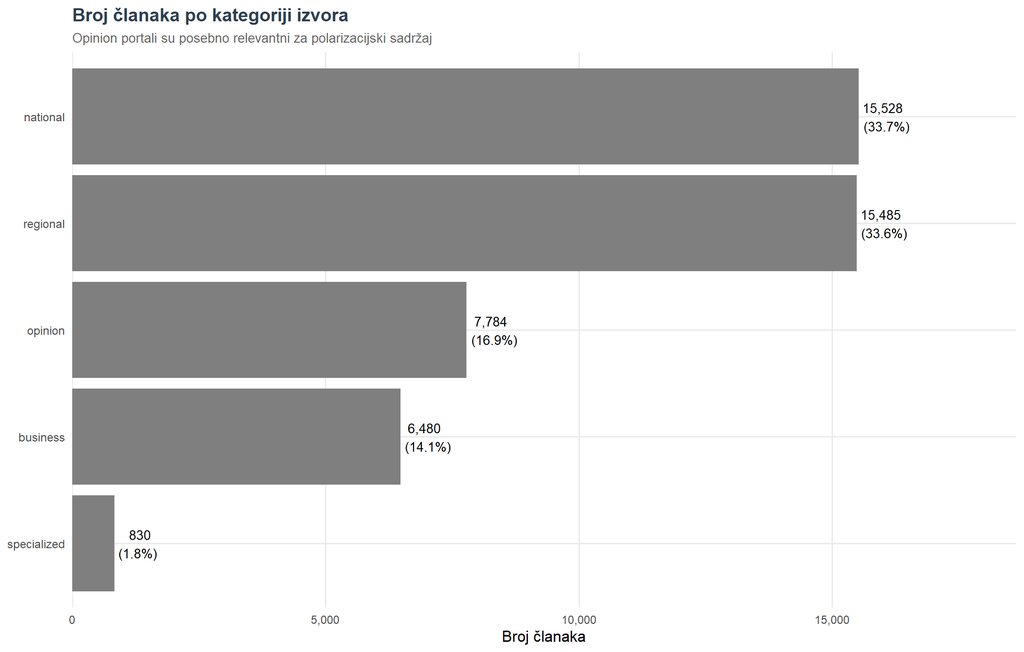

Distribucija članaka po kategorijama izvora

## 3.3 Top 20 izvora

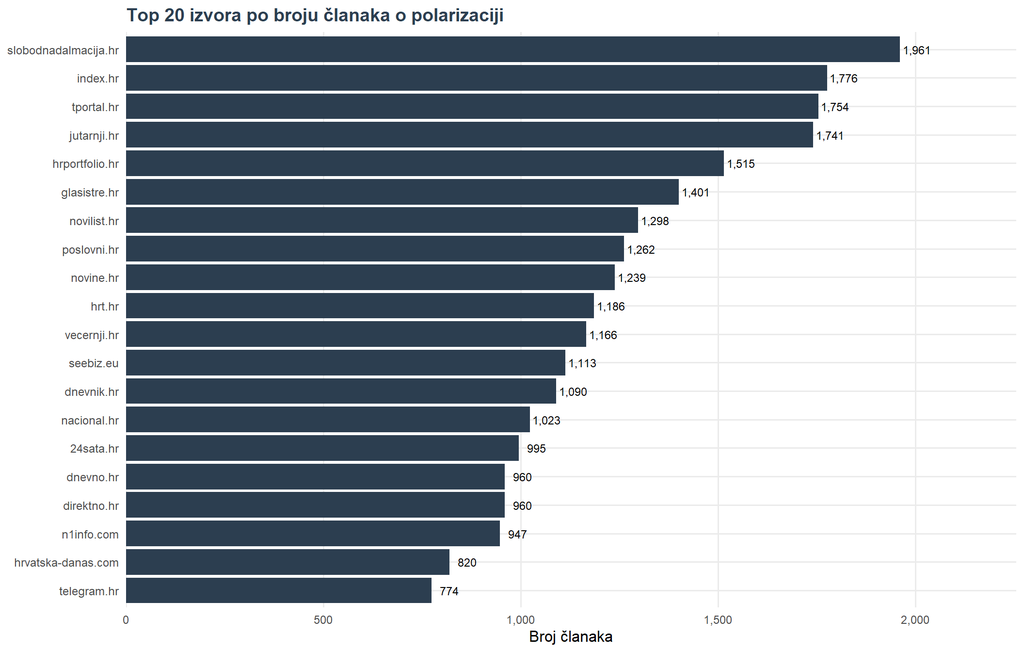

20 najaktivnijih izvora

## 3.4 Distribucija duljine teksta

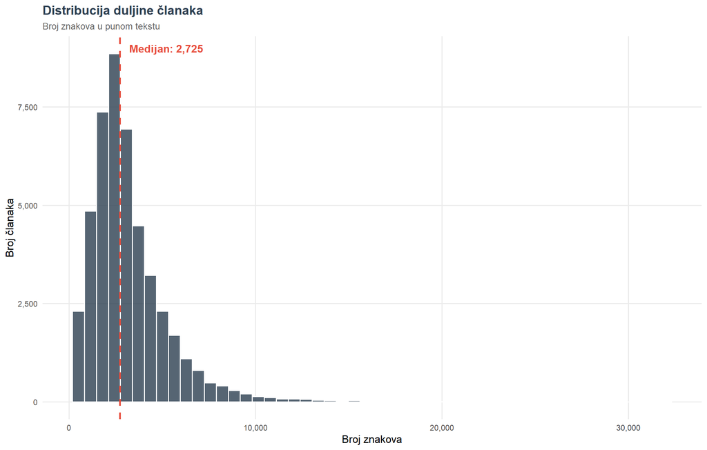

Distribucija duljine članaka

# 4 Semantička taksonomija

## 4.1 Hijerarhijska struktura pojmova

Semantička taksonomija se organizira u 12 makro kategorija koje obuhvaćaju različite aspekte polarizacijskog diskursa u hrvatskom kontekstu. Pojmovi se definiraju pomoću korijena riječi (stem) kako bi se osigurala šira morfološka pokrivenost hrvatskog jezika.

**Detaljna metodologija semantičke taksonomije**

**Princip konstrukcije rječnika:**

1. Kategorije predstavljaju konceptualno različite aspekte polarizacije
2. Regex uzorci se koriste za fleksibilno prepoznavanje morfoloških varijanti
3. Korijenski oblici osiguravaju prepoznavanje svih padežnih i glagolskih oblika

**Formula za brojanje:**

$$\text{count}_{c,d} = \sum_{p \in P_c} \text{matches}(p, d)$$

gdje je $P_c$ skup regex uzoraka za kategoriju $c$, a $d$ je tekst dokumenta.

Pregled rječnika semantičkih pojmova za polarizaciju

| Kategorija | Broj pojmova | Primjeri regex uzoraka |
| --- | --- | --- |
| Polarizacija i podjele | 7 | polarizacij[a-zčćžšđ]*, podijeljen[a-zčćžšđ]* |
| Lijevo desno spektar | 12 | ljevic[a-zčćžšđ]*, desnic[a-zčćžšđ]* |
| Stranački sukobi | 8 | (hdz&#124;sdp).{0,20}(sukob&#124;napad&#124;optu[zž]&#124;protiv&#124;kritik), (mo[zž]emo&#124;most&#124;dp).{0,20}(sukob&#124;napad&#124;optu[zž]&#124;protiv) |
| Govor mržnje | 5 | govor[a-zčćžšđ]*.{0,5}mr[zž]nj[a-zčćžšđ]*, mr[zž]nj[aeiou]+[a-zčćžšđ]* |
| Netolerancija i diskriminacija | 10 | ksenofobij[a-zčćžšđ]*, homofobij[a-zčćžšđ]* |
| Povijesni sukobi | 9 | usta[sš][a-zčćžšđ]*, partizan[a-zčćžšđ]* |
| Rodna pitanja i LGBT | 8 | rodn[a-zčćžšđ]*.{0,10}ideologij[a-zčćžšđ]*, istanbulsk[a-zčćžšđ]*.{0,10}konvencij[a-zčćžšđ]* |
| Pobačaj i pro life | 7 | poba[cč]aj[a-zčćžšđ]*, pravo.{0,10}poba[cč]aj |
| Crkva i država | 7 | crkv[a-zčćžšđ]*.{0,15}(politi&#124;dr[zž]av&#124;utjecaj), vjeronauk[a-zčćžšđ]* |
| Migracije | 5 | migrant[a-zčćžšđ]*, izbjegli[ck][a-zčćžšđ]* |
| Dezinformacije i propaganda | 9 | dezinformacij[a-zčćžšđ]*, la[zž]n[a-zčćžšđ]*.{0,5}vijesti |
| Identitetska politika | 10 | identitetsk[a-zčćžšđ]*.{0,10}politik[a-zčćžšđ]*, politi[cč]k[a-zčćžšđ]*.{0,5}rat |

## 4.2 Brojanje semantičkih pojmova

## 4.3 Dinamika semantičkih kategorija

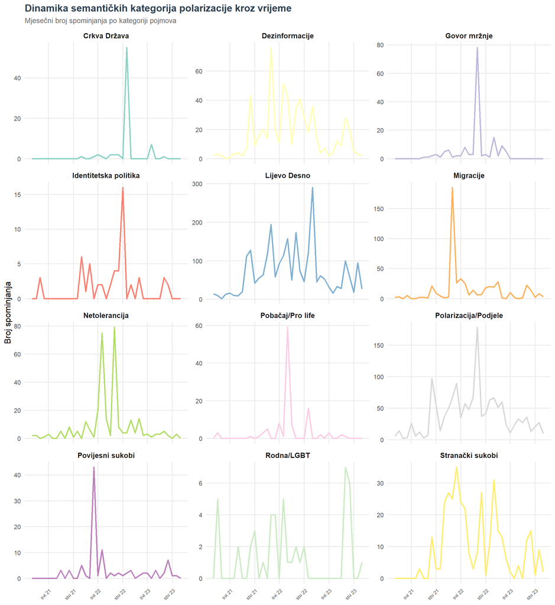

Dinamika semantičkih kategorija kroz vrijeme

# 5 Konstrukcija indeksa

### 5.0.1 Political Polarization Index (PPI)

PPI kvantificira opću razinu polarizacijskog diskursa u medijima mjereći intenzitet pojmova koji direktno opisuju polarizaciju, podjele i rascjepe u društvu. Konstrukcija se temelji na prebrojavanju pojavljivanja korijena riječi poput polarizacij, podijeljen, podjel, rascjep, razdor i slično. Suma tih pojavljivanja normalizira se brojem članaka kako bi se dobila prosječna mjesečna frekvencija pojmova polarizacije. Rezultat se skalira na raspon 0 do 100 standardnom min max normalizacijom. Povišene vrijednosti PPI indeksa indiciraju intenzivan medijski diskurs o podjelama u društvu.

**Detaljna metodologija PPI indeksa**

**Formula:**

$$\text{PPI}_t = \text{normalize}_{0-100}\left(\frac{\text{count}_{polarizacija,t}}{N_t}\right)$$

**Uključeni pojmovi:** polarizacija, podijeljenost, podjela, rascjep, razdor, podvojenost, društvene/političke podjele

### 5.0.2 Party Division Index (PDI)

PDI prati intenzitet sukoba između političkih stranaka u medijskom izvještavanju. Indeks se konstruira prebrojavanjem pojavljivanja pojmova vezanih uz međustranačke sukobe normaliziranih ukupnim brojem članaka. Vrhovi ukazuju na periode intenzivnih međustranačkih sukoba, često vezanih uz izbore ili političke krize.

**Detaljna metodologija PDI indeksa**

**Formula:**

$$\text{PDI}_t = \text{normalize}_{0-100}\left(\frac{\text{count}_{stranački,t}}{N_t}\right)$$

**Uključeni pojmovi:** HDZ SDP sukobi, vladajući opozicija, stranački sukobi, politički obračuni, koalicijske krize

### 5.0.3 Hate Speech Index (HSI)

HSI mjeri prisutnost govora mržnje i netolerancije u medijskom prostoru. Indeks kombinira pojmove vezane uz govor mržnje i pojmove vezane uz različite oblike diskriminacije i netolerancije. Visoke vrijednosti signaliziraju pojačan diskurs o netoleranciji i diskriminaciji.

**Detaljna metodologija HSI indeksa**

**Formula:**

$$\text{HSI}_t = \text{normalize}_{0-100}\left(\frac{\text{count}_{mržnja,t} + \text{count}_{netolerancija,t}}{N_t}\right)$$

**Uključeni pojmovi:** govor mržnje, mržnja, poticanje mržnje, ksenofobija, homofobija, rasizam, antisemitizam, diskriminacija, stigmatizacija

### 5.0.4 Historical Conflict Index (HCI)

HCI prati diskurs o povijesnim podjelama i traumama iz Drugog svjetskog rata i Domovinskog rata. Indeks je posebno relevantan za hrvatski kontekst s obzirom na nerazriješene povijesne traume. Vrhovi često koincidiraju s komemoracijama, političkim izjavama o prošlosti ili kontroverznim simbolima.

**Detaljna metodologija HCI indeksa**

**Formula:**

$$\text{HCI}_t = \text{normalize}_{0-100}\left(\frac{\text{count}_{povijesni,t}}{N_t}\right)$$

**Uključeni pojmovi:** ustaše, partizani, NDH, Za dom spremni, Jasenovac, Bleiburg, Križni put, revizija povijesti, instrumentalizacija prošlosti

### 5.0.5 Culture War Index (CWI)

CWI mjeri intenzitet diskursa o spornim društvenim pitanjima vezanim uz rod, LGBT prava i reproduktivna prava. Indeks kombinira pojmove iz kategorija rodnih pitanja i pobačaja. Visoke vrijednosti ukazuju na intenzivne društvene debate o vrijednosnim pitanjima.

**Detaljna metodologija CWI indeksa**

**Formula:**

$$\text{CWI}_t = \text{normalize}_{0-100}\left(\frac{\text{count}_{rodna\_lgbt,t} + \text{count}_{pobačaj,t}}{N_t}\right)$$

**Uključeni pojmovi:** rodna ideologija, Istanbulska konvencija, istospolni brak/zajednica, LGBT, Pride, pobačaj, Hod za život, pro life

### 5.0.6 Church State Index (CSI)

CSI prati tenzije između sekularnog i vjerskog u javnom prostoru. Indeks mjeri intenzitet diskursa o ulozi Crkve u politici i javnom životu. Visoke vrijednosti signaliziraju intenzivne debate o utjecaju Crkve na javne politike.

**Detaljna metodologija CSI indeksa**

**Formula:**

$$\text{CSI}_t = \text{normalize}_{0-100}\left(\frac{\text{count}_{crkva,t}}{N_t}\right)$$

**Uključeni pojmovi:** crkva i politika, vjeronauk, križ u školama, sekularizam, klerikalizam, utjecaj Crkve na politiku

### 5.0.7 Migration Issue Index (MII)

MII mjeri intenzitet polarizacije oko tema vezanih uz migracije i izbjeglice. Vrhovi koincidiraju s migracijskim krizama ili političkim debatama o migrantima.

**Detaljna metodologija MII indeksa**

**Formula:**

$$\text{MII}_t = \text{normalize}_{0-100}\left(\frac{\text{count}_{migracije,t}}{N_t}\right)$$

**Uključeni pojmovi:** migranti, izbjeglice, azilanti, anti migracija, sukobi vezani uz migrante

### 5.0.8 Disinformation Index (DII)

DII prati diskurs o lažnim vijestima, propagandi i informacijskom ratu. Visoke vrijednosti ukazuju na intenzivan diskurs o medijskoj manipulaciji i teorijama zavjere.

**Detaljna metodologija DII indeksa**

**Formula:**

$$\text{DII}_t = \text{normalize}_{0-100}\left(\frac{\text{count}_{dezinformacije,t}}{N_t}\right)$$

**Uključeni pojmovi:** dezinformacije, lažne vijesti, fake news, propaganda, manipulacija, botovi, informacijski rat, teorije zavjere

### 5.0.9 Left Right Index (LRI)

LRI mjeri intenzitet ideološkog diskursa na lijevo desnom spektru. Visoke vrijednosti signaliziraju intenzivne ideološke debate o pozicioniranju na političkom spektru.

**Detaljna metodologija LRI indeksa**

**Formula:**

$$\text{LRI}_t = \text{normalize}_{0-100}\left(\frac{\text{count}_{lijevo\_desno,t}}{N_t}\right)$$

**Uključeni pojmovi:** ljevica, desnica, lijevi, desni, konzervativci, liberali, progresivci, nacionalisti, populisti, suverenisti

### 5.0.10 Composite Polarization Index (CPI)

CPI predstavlja kompozitni indeks polarizacije koji agregira sve pojedinačne indekse u jednu mjeru ukupnog polarizacijskog diskursa. Izračunava se kao jednostavni prosjek svih 10 specijaliziranih indeksa čime se osigurava jednaka težina svakom aspektu polarizacije. Visoke vrijednosti indiciraju razdoblja intenzivnog polarizacijskog diskursa općenito.

**Detaljna metodologija CPI indeksa**

**Formula:**

$$\text{CPI}_t = \frac{1}{10} \sum_{i=1}^{10} \text{Indeks}_{i,t}$$

**Interpretacija vrijednosti:**

Raspon 0 do 25 indicira nisku razinu polarizacijskog diskursa. Raspon 25 do 50 indicira umjerenu razinu. Raspon 50 do 75 indicira visoku razinu. Raspon 75 do 100 indicira vrlo visoku razinu tipičnu za krizna razdoblja.

## 5.1 Opis indeksa

Pregled konstruiranih indeksa

| Indeks | Naziv | Opis |
| --- | --- | --- |
| PPI | Political Polarization Index | Opća razina polarizacijskog diskursa |
| PDI | Party Division Index | Intenzitet stranačkih sukoba |
| HSI | Hate Speech Index | Govor mržnje i netolerancija |
| HCI | Historical Conflict Index | Povijesne podjele i traume |
| CWI | Culture War Index | Kulturni ratovi (rod, LGBT, pobačaj) |
| CSI | Church State Index | Tenzije crkva država |
| MII | Migration Issue Index | Polarizacija oko migracija |
| DII | Disinformation Index | Dezinformacije i propaganda |
| LRI | Left Right Index | Lijevo desni diskurs |
| IPI | Identity Politics Index | Identitetska politika |
| CPI | Composite Polarization Index | Kompozitni indeks svih kategorija |

# 6 Vizualizacija indeksa

## 6.1 Glavni indeksi

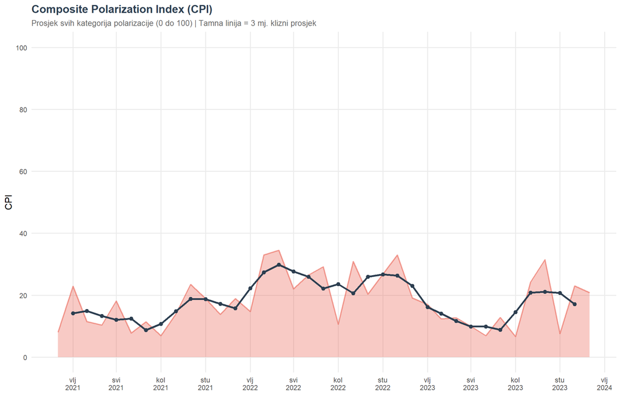

Composite Polarization Index (CPI)

## 6.2 Indeksi političkih sukoba

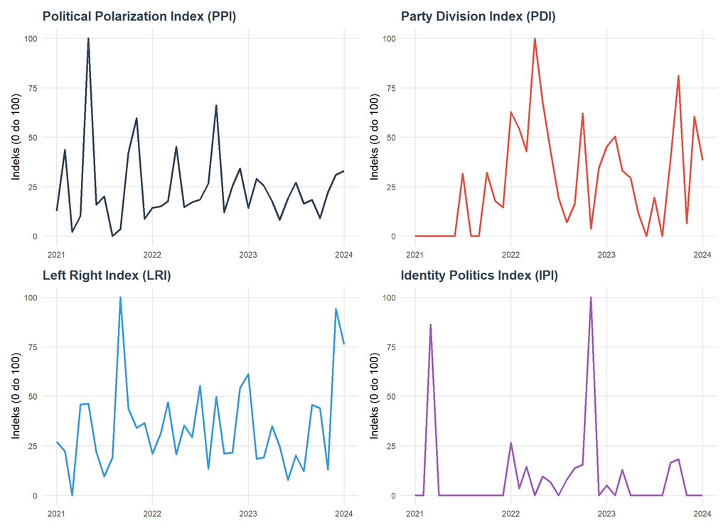

Indeksi političkih sukoba: PPI, PDI, LRI, IPI

## 6.3 Indeksi društvenih sukoba

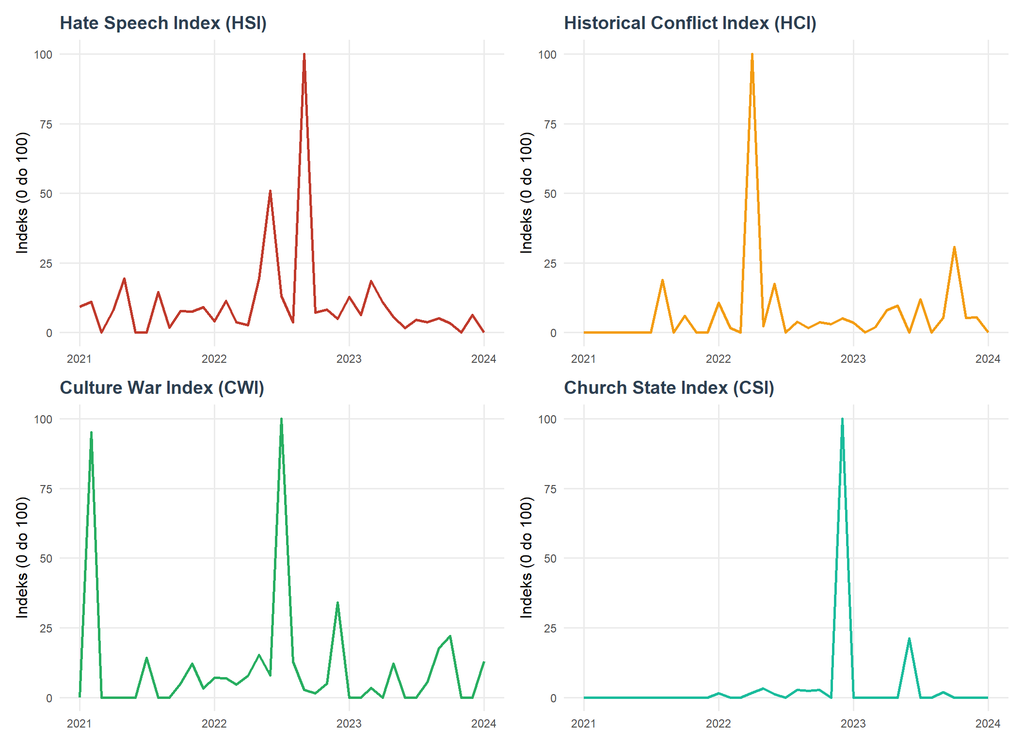

Indeksi društvenih sukoba: HSI, HCI, CWI, CSI

## 6.4 Indeksi specifičnih tema

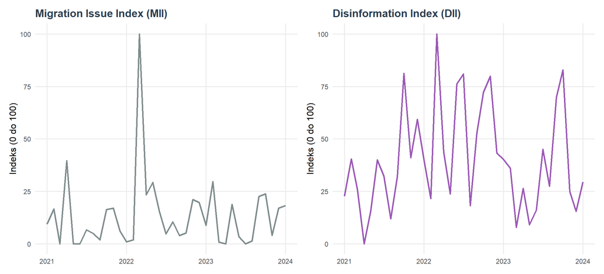

Migration Issue Index (MII) i Disinformation Index (DII)

## 6.5 Tablica indeksa

Indeksi polarizacije: zadnjih 12 mjeseci

| Mjesec | Broj članaka | CPI | PPI | PDI | HSI | HCI | CWI |
| --- | --- | --- | --- | --- | --- | --- | --- |
| vlj 2023 | 1,405 | 17.0 | 29.0 | 50.4 | 6.3 | 0.0 | 0.0 |
| ožu 2023 | 1,848 | 12.3 | 25.5 | 33.2 | 18.5 | 2.1 | 3.5 |
| tra 2023 | 959 | 12.7 | 17.6 | 29.5 | 10.8 | 8.0 | 0.0 |
| svi 2023 | 793 | 10.0 | 8.3 | 11.9 | 5.6 | 9.7 | 12.1 |
| lip 2023 | 904 | 6.9 | 19.0 | 0.0 | 1.6 | 0.0 | 0.0 |
| srp 2023 | 964 | 12.8 | 27.1 | 19.6 | 4.6 | 12.0 | 0.0 |
| kol 2023 | 1,184 | 6.7 | 16.5 | 0.0 | 3.8 | 0.0 | 5.4 |
| ruj 2023 | 1,451 | 24.2 | 18.4 | 39.1 | 5.1 | 5.3 | 17.7 |
| lis 2023 | 874 | 31.5 | 9.2 | 81.1 | 3.4 | 30.8 | 22.0 |
| stu 2023 | 728 | 7.6 | 22.1 | 6.5 | 0.0 | 5.3 | 0.0 |
| pro 2023 | 702 | 23.0 | 31.0 | 60.5 | 6.3 | 5.5 | 0.0 |
| sij 2024 | 246 | 20.8 | 33.0 | 38.4 | 0.0 | 0.0 | 13.0 |

# 7 Sektorska analiza

## 7.1 Dinamika po sektorima

[figure not shown]

Dinamika polarizacijskih kategorija po tipu izvora

## 7.2 Heatmapa sektorske aktivnosti

[figure not shown]

Heatmapa intenziteta polarizacijskih kategorija kroz vrijeme

## 7.3 Korelacijska struktura

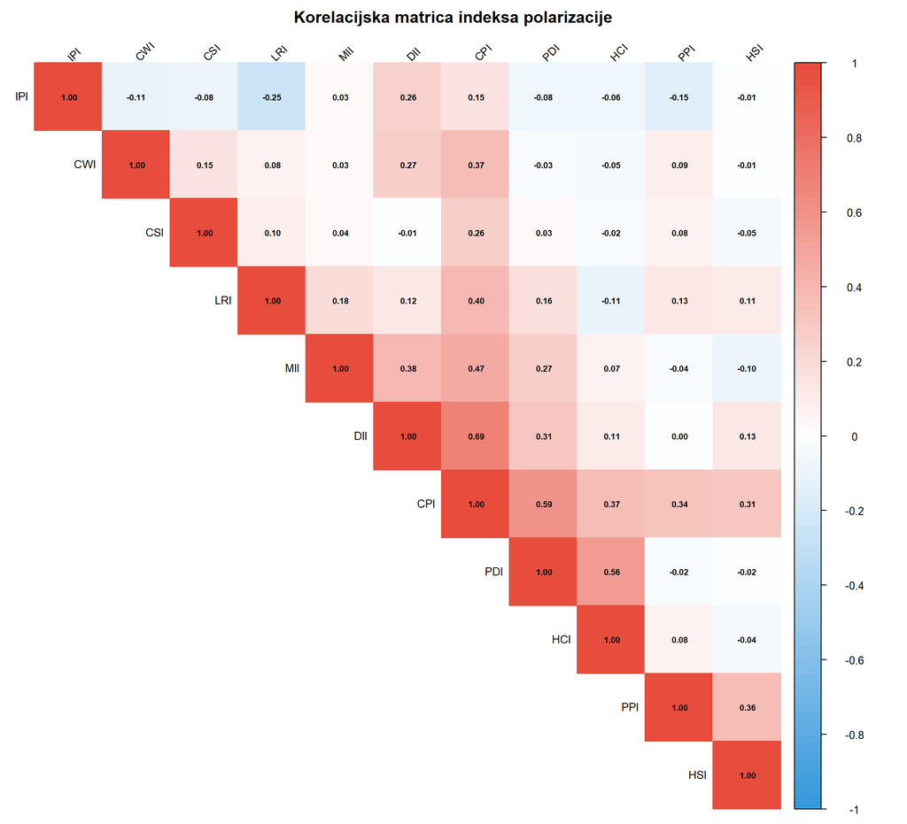

Korelacijska matrica indeksa polarizacije

# 8 Sentiment analiza

## 8.1 Konstrukcija sentiment leksikona

## 8.2 Dinamika sentimenta kroz vrijeme

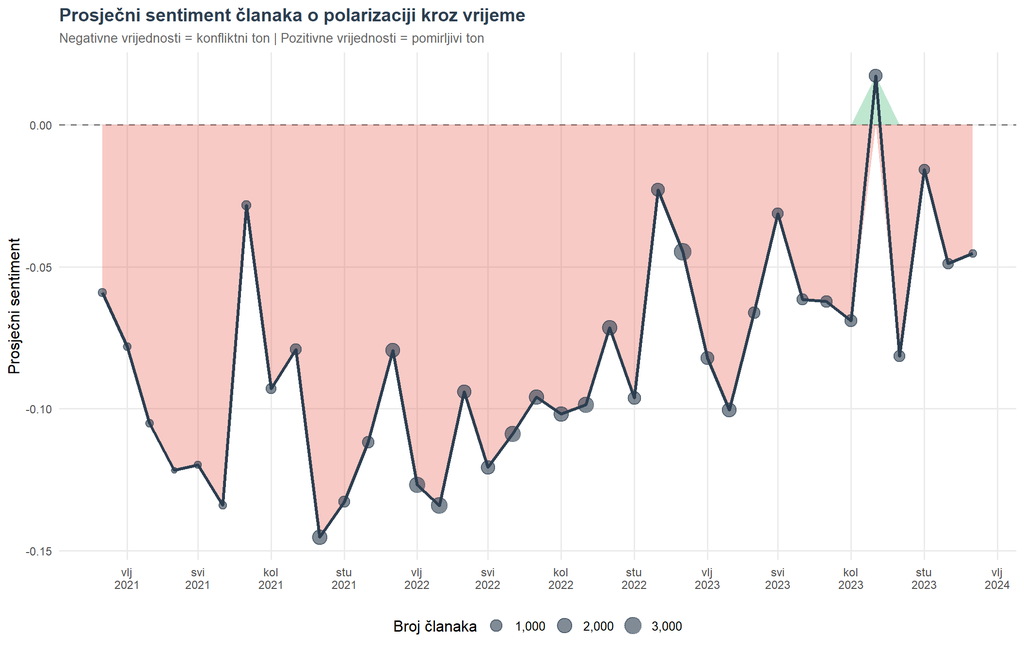

Dinamika sentimenta kroz vrijeme

## 8.3 Distribucija sentimenta

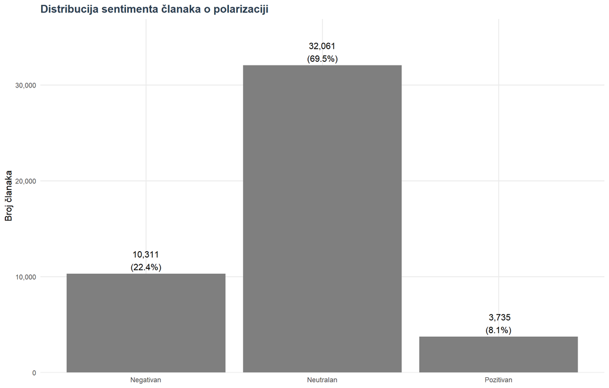

Distribucija sentimenta članaka

# 9 Volatilnost i momentum

## 9.1 Konstrukcija volatilnosti i momentuma

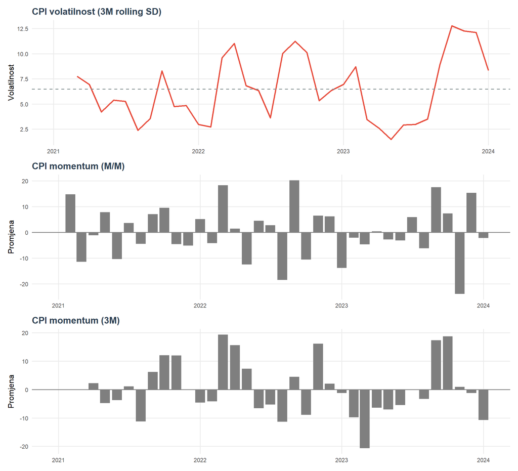

CPI volatilnost i momentum

[figure not shown]

Standardizirani indeksi volatilnosti i momentuma

# 10 Koncentracija tema

## 10.1 Konstrukcija mjera koncentracije

**Metodologija HHI indeksa**

Herfindahl Hirschman Index (HHI) mjeri koncentraciju tema u medijskom prostoru. Izračunava se kao suma kvadrata udjela svake kategorije. Vrijednosti bliže 1 indiciraju visoku koncentraciju (dominacija jedne teme), dok vrijednosti bliže 0 indiciraju ravnomjerniju raspodjelu pozornosti.

**Formula:**

$$\text{HHI}_t = \sum_{i=1}^{n} s_{i,t}^2$$

gdje je $s_{i,t}$ udio kategorije $i$ u ukupnom broju spominjanja u mjesecu $t$.

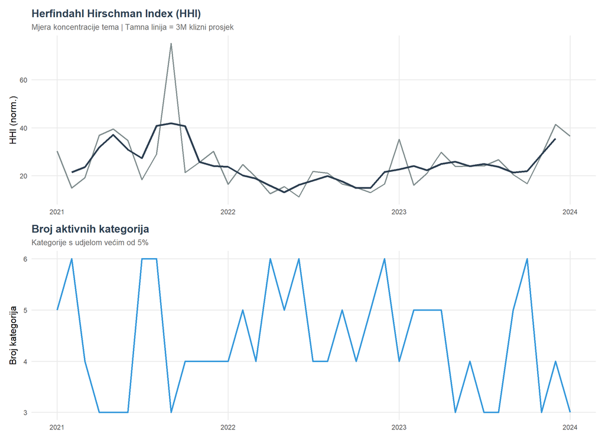

Koncentracija tema (HHI) i broj aktivnih kategorija

# 11 Korelacije između indeksa

Korelacije pojedinačnih indeksa s Composite Polarization Index

| Indeks | Korelacija s CPI |
| --- | --- |
| DII | 0.690 |
| PDI | 0.589 |
| MII | 0.470 |
| LRI | 0.397 |
| CWI | 0.372 |
| HCI | 0.371 |
| PPI | 0.339 |
| HSI | 0.310 |
| CSI | 0.260 |
| IPI | 0.154 |

# 12 Export

# 13 Sažetak

Sažetak ključnih nalaza analize

| Nalaz | Vrijednost |
| --- | --- |
| Ukupno analiziranih članaka | 46,107 |
| Vremenski raspon analize | 01/2021 do 01/2024 |
| Broj izvora | 115 |
| Vrh CPI indeksa | travanj 2022 |
| Vrijednost vrha | 34.5 |
| Dominantna kategorija | Disinformation |
| Prosječna vrijednost | 40.2 |
| Prosječni CPI | 18.2 |
| Standardna devijacija CPI | 8.5 |

*Izvještaj generiran: 2026-01-02 13:45:58.684852*

*GIMES Research | Analiza medijske pokrivenosti političke polarizacije v2.0*